# Examen Clasificación Febrero 2019

Arturo Sánchez Palacio

# Carga de datos

En primer lugar se cargan los datos en R:

```r
library(openxlsx)
```

[output not shown]

```r
data <- read.xlsx("./data/BDexamen2.xlsx")
```

Se comprueba que se han cargado de manera correcta:

```r
dim(data)
```

```
[1] 4220   11
```

```r
str(data)
```

```
'data.frame':   4220 obs. of  11 variables:
 $ TAMAMU  : num  0 1 1 0 1 1 1 0 1 1 ...
 $ DENSIDAD: num  2 1 2 3 2 2 1 3 1 1 ...
 $ EDAD    : chr  "74" "51" "54" "42" ...
 $ SEXO    : num  0 1 0 1 0 0 0 0 1 0 ...
 $ ESTUD   : num  2 2 1 1 3 2 2 2 4 1 ...
 $ LAB     : num  4 3 3 1 3 3 3 4 1 4 ...
 $ REGTEN  : num  1 1 1 1 1 1 0 0 0 0 ...
 $ SUPERF  : num  78 78 91 150 90 90 60 75 95 50 ...
 $ IMPEXAC : num  6.57 0 4.26 0 0 4.26 5.5 7.43 3.5 7.42 ...
 $ cat2    : num  0 0 0 0 0 0 0 0 0 0 ...
 $ cat3    : num  1 1 1 1 1 1 1 1 1 1 ...
```

Se observa que muchas de las variables categóricas han sido cargadas como numéricas y se procede a subsanar el error:

```r
data$cat2 <- as.factor(data$cat2)
data$cat3 <- as.factor(data$cat3)
data$DENSIDAD <- as.factor(data$DENSIDAD)
data$TAMAMU <- as.factor(data$TAMAMU)
data$SEXO <- as.factor(data$SEXO)
data$ESTUD <- as.factor(data$ESTUD)
data$LAB <- as.factor(data$LAB)
data$REGTEN <- as.factor(data$REGTEN)
```

Además la variable edad se ha leído como string siendo un entero. Comprobamos que no hay nada raro en ella y la transformamos en entero:

```r
unique(data$EDAD)
```

```
 [1] "74" "51" "54" "42" "58" "45" "72" "41" "85" "36" "49" "61" "32" "50" "38" "60" "84" "43" "53" "71" "26"
[22] "29" "75" "63" "47" "56" "52" "70" "73" "81" "39" "80" "83" "78" "48" "28" "33" "40" "67" "44" "34" "57"
[43] "62" "55" "76" "22" "24" "79" "35" "46" "66" "77" "82" "65" "23" "68" "59" "64" "69" "20" "37" "25" "30"
[64] "31" "27" "21" "18"
```

```r
data$EDAD <- as.integer(data$EDAD)
```

Si observamos ahora los datos ya encuentran en un formato óptimo para trabajar con ellos:

```r
str(data)
```

```
'data.frame':   4220 obs. of  11 variables:
 $ TAMAMU  : Factor w/ 2 levels "0","1": 1 2 2 1 2 2 2 1 2 2 ...
 $ DENSIDAD: Factor w/ 3 levels "1","2","3": 2 1 2 3 2 2 1 3 1 1 ...
 $ EDAD    : int  74 51 54 42 54 58 45 72 41 85 ...
 $ SEXO    : Factor w/ 2 levels "0","1": 1 2 1 2 1 1 1 1 2 1 ...
 $ ESTUD   : Factor w/ 4 levels "1","2","3","4": 2 2 1 1 3 2 2 2 4 1 ...
 $ LAB     : Factor w/ 4 levels "1","2","3","4": 4 3 3 1 3 3 3 4 1 4 ...
 $ REGTEN  : Factor w/ 2 levels "0","1": 2 2 2 2 2 2 1 1 1 1 ...
 $ SUPERF  : num  78 78 91 150 90 90 60 75 95 50 ...
 $ IMPEXAC : num  6.57 0 4.26 0 0 4.26 5.5 7.43 3.5 7.42 ...
 $ cat2    : Factor w/ 2 levels "0","1": 1 1 1 1 1 1 1 1 1 1 ...
 $ cat3    : Factor w/ 3 levels "1","2","3": 1 1 1 1 1 1 1 1 1 1 ...
```

Finalmente una vez los datos se han limpiado se lleva a cabo un pequeño análisis exploratorio.

# Análisis exploratorio

Para realizar el análisis exploratorio se dividen las variables en numéricas y categóricas pues se emplean distintos análisis para cada tipo.

Para las variables numéricas:

```r
numeric <- data[,c(3, 8,9)]
summary(numeric)
```

```
      EDAD           SUPERF          IMPEXAC
 Min.   :18.00   Min.   : 35.00   Min.   :  0.00
 1st Qu.:50.00   1st Qu.: 67.00   1st Qu.:  7.45
 Median :63.00   Median : 85.00   Median : 10.05
 Mean   :61.57   Mean   : 90.95   Mean   : 11.84
 3rd Qu.:75.00   3rd Qu.:100.00   3rd Qu.: 15.00
 Max.   :85.00   Max.   :300.00   Max.   :152.07
                 NA's   :168
```

```r
print("Varianzas:")
```

```
[1] "Varianzas:"
```

```r
apply(numeric, 2, var)
```

```
     EDAD    SUPERF   IMPEXAC
263.86342        NA  57.77589
```

y en cuanto a las variables categóricas:

```r
cualitative <- data[, c(1,2,4:7,10,11)]
summary(cualitative)
```

```
 TAMAMU   DENSIDAD SEXO     ESTUD    LAB      REGTEN   cat2     cat3
 0: 946   1:2191   0:2483   1:1212   1:1363   0:1371   0:2210   1:1472
 1:3274   2: 910   1:1737   2:1126   2: 152   1:2849   1:2010   2:1473
          3:1119            3: 707   3: 367                     3:1275
                            4:1175   4:2338
```

# Tratamiento de los NA

La base de datos solo presenta 168 valores no definidos todos ellos situados en la columan superficie. Se plantean dos opciones para subsanar este problema:

Elimanar las observaciones con NA por no llegar a suponer estas un 4% de la muestra:

```r
#data <- na.omit(data)
```

Sustituir los NA’s por la media o la mediana (realmente en el summary se aprecia que están muy próximas):

```r
data$SUPERF[is.na(data$SUPERF)] <- mean(data$SUPERF,na.rm = T)
numeric <- data[,c(3, 8,9)]
```

En este caso nos hemos dectando por sustituir por la media

Una vez se han tratado los NA’s y se han explorado las variables se puede proceder al análisis pedido.

Sobre las variables numéricas se puede llevar a cabo así mismo un análisis de correlación ahora que se han elimnado los NA’s:

```r
cor(numeric)
```

```
              EDAD    SUPERF    IMPEXAC
EDAD     1.0000000 0.1839569 -0.1341252
SUPERF   0.1839569 1.0000000  0.1385968
IMPEXAC -0.1341252 0.1385968  1.0000000
```

Las variables numéricas se encuentran poco correlacionadas entre sí.

# Clasificación respecto a la variable cat2 (sin considerar cat3)

Para proceder a dicha clasificación es necesario eliminar la variable cat3 de nuestra base de datos. Además debido a la gran diferencia entre las varianzas de las variables numéricas se procede a su tificación:

```r
datacat2 <- data[,-11]
datacat2$SUPERF <- scale(datacat2$SUPERF)
datacat2$EDAD <- scale(datacat2$EDAD)
datacat2$IMPEXAC <- scale(datacat2$IMPEXAC)
```

Una vez hecho esto se procede al análisis logístico:

En primer lugar se fija una semilla para garantizar la reproductibilidad del experimento. Tras ello se divide la base de datos en una muestra de entrenamiento y otra de test:

```r
set.seed(1234)
train <- sample(nrow(datacat2), 0.8*nrow(datacat2))
data.train <- datacat2[train,]
data.test <- datacat2[-train,]
```

Una vez hecho esto se comprueba que las muestras estén balanceadas:

```r
table(data.train$cat2)
```

```
   0    1
1793 1583
```

```r
table(data.test$cat2)
```

```
  0   1
417 427
```

Las muestras están balanceadas por lo que se puede proseguir con el proceso de clasifacación.

Dado que en la base de datos existen tanto variables cuantitativas como cualitativas se emplearán modelos de regresión logística. Construimos un primer modelo base que emplea todas las variables disponibles:

```r
basic.model <- glm(cat2 ~.,family = binomial(link = 'logit'),data = data.train)
```

```
glm.fit: fitted probabilities numerically 0 or 1 occurred
```

Se obtiene un resumen de dicho modelo inicial:

```r
summary(basic.model)
```

```
Call:
glm(formula = cat2 ~ ., family = binomial(link = "logit"), data = data.train)

Deviance Residuals:
    Min       1Q   Median       3Q      Max
-3.0574  -0.4211  -0.0208   0.5279   3.5450

Coefficients:
            Estimate Std. Error z value Pr(>|z|)
(Intercept) -3.92548    0.31857 -12.322  < 2e-16 ***
TAMAMU1     -0.14361    0.17395  -0.826  0.40904
DENSIDAD2   -0.58327    0.14335  -4.069 4.72e-05 ***
DENSIDAD3   -0.47316    0.18119  -2.611  0.00902 **
EDAD         0.05838    0.09932   0.588  0.55665
SEXO1       -0.31083    0.11570  -2.687  0.00722 **
ESTUD2       0.21528    0.13503   1.594  0.11088
ESTUD3       0.17201    0.20079   0.857  0.39161
ESTUD4       0.06604    0.21927   0.301  0.76326
LAB2        -1.60221    0.36430  -4.398 1.09e-05 ***
LAB3        -2.17478    0.28745  -7.566 3.85e-14 ***
LAB4        -1.33280    0.23900  -5.577 2.45e-08 ***
REGTEN1      7.11610    0.30998  22.956  < 2e-16 ***
SUPERF       0.10124    0.05578   1.815  0.06954 .
IMPEXAC      2.60220    0.13797  18.860  < 2e-16 ***
---
Signif. codes:  0 ‘***’ 0.001 ‘**’ 0.01 ‘*’ 0.05 ‘.’ 0.1 ‘ ’ 1

(Dispersion parameter for binomial family taken to be 1)

    Null deviance: 4667.1  on 3375  degrees of freedom
Residual deviance: 2291.8  on 3361  degrees of freedom
AIC: 2321.8

Number of Fisher Scoring iterations: 7
```

Las variables más importantes parecen ser el régimen de tenencia, el sexo, la densidad de población de la zona de residencia, la situación laboral y los ingresos mensuales. En menor medida la superficie tampoco parece desdeñable. Se construye un nuevo modelo que solo tenga en consideración dichas variables:

```r
refined.model <- glm(cat2 ~ DENSIDAD + SEXO + LAB + REGTEN + SUPERF + IMPEXAC,family = binomial(link = 'logit'),data = data.train)
```

```
glm.fit: fitted probabilities numerically 0 or 1 occurred
```

Obtenemos de nuevo un resumen del modelo:

```r
summary(refined.model)
```

```
Call:
glm(formula = cat2 ~ DENSIDAD + SEXO + LAB + REGTEN + SUPERF +
    IMPEXAC, family = binomial(link = "logit"), data = data.train)

Deviance Residuals:
    Min       1Q   Median       3Q      Max
-3.0861  -0.4237  -0.0205   0.5354   3.5338

Coefficients:
            Estimate Std. Error z value Pr(>|z|)
(Intercept) -4.03326    0.23166 -17.410  < 2e-16 ***
DENSIDAD2   -0.56363    0.14021  -4.020 5.83e-05 ***
DENSIDAD3   -0.38290    0.12724  -3.009  0.00262 **
SEXO1       -0.30983    0.11388  -2.721  0.00651 **
LAB2        -1.59341    0.36376  -4.380 1.18e-05 ***
LAB3        -2.16391    0.28682  -7.545 4.54e-14 ***
LAB4        -1.30981    0.19208  -6.819 9.16e-12 ***
REGTEN1      7.19049    0.30766  23.371  < 2e-16 ***
SUPERF       0.10724    0.05538   1.936  0.05282 .
IMPEXAC      2.61310    0.13370  19.545  < 2e-16 ***
---
Signif. codes:  0 ‘***’ 0.001 ‘**’ 0.01 ‘*’ 0.05 ‘.’ 0.1 ‘ ’ 1

(Dispersion parameter for binomial family taken to be 1)

    Null deviance: 4667.1  on 3375  degrees of freedom
Residual deviance: 2295.4  on 3366  degrees of freedom
AIC: 2315.4

Number of Fisher Scoring iterations: 7
```

Se ha reducido el AIC por lo que el modelo no solo se simplifica si no que mejora. Realizamos un test ANOVA sobre el modelo:

```r
anova(refined.model, test = "Chisq")
```

```
Analysis of Deviance Table

Model: binomial, link: logit

Response: cat2

Terms added sequentially (first to last)

         Df Deviance Resid. Df Resid. Dev  Pr(>Chi)
NULL                      3375     4667.1
DENSIDAD  2    17.69      3373     4649.4 0.0001441 ***
SEXO      1    13.28      3372     4636.1 0.0002679 ***
LAB       3   258.57      3369     4377.5 < 2.2e-16 ***
REGTEN    1  1291.72      3368     3085.8 < 2.2e-16 ***
SUPERF    1    34.09      3367     3051.7 5.256e-09 ***
IMPEXAC   1   756.34      3366     2295.4 < 2.2e-16 ***
---
Signif. codes:  0 ‘***’ 0.001 ‘**’ 0.01 ‘*’ 0.05 ‘.’ 0.1 ‘ ’ 1
```

La superficie de cuya capacidad clasificadora se dudaba en un principio parece finalmente aportar información relevante que se perdería si se prescindiera de ella así que debe mantenerse. De la misma manera todas las variables tienen un nivel de significación alto por lo que este será nuestro modelo definitivo.

```r
library(pscl)
pR2(basic.model)
```

```
          llh       llhNull            G2      McFadden          r2ML          r2CU
-1145.8940800 -2333.5292649  2375.2703699     0.5089438     0.5051870     0.6744548
```

```r
pR2(refined.model)
```

```
          llh       llhNull            G2      McFadden          r2ML          r2CU
-1147.6809421 -2333.5292649  2371.6966457     0.5081780     0.5046629     0.6737551
```

Así una vez elegido el modelo vamos a testear con el conjunto de validación obteniendo la matriz de confusión:

```r
fitted.results <- predict(refined.model, newdata = data.test, type = 'response')
fitted.results <- ifelse(fitted.results > 0.5,1,0)
fitted.results <- factor(fitted.results, levels = c(0,1), labels = c("Bajo", "No bajo"))
(logit.perf <- table(data.test$cat2, fitted.results, dnn = c("Actual", "Predicted")))
```

```
      Predicted
Actual Bajo No bajo
     0  344      73
     1   75     352
```

y el accuracy:

```r
print(paste('Accuracy',sum(diag(logit.perf))/sum(logit.perf)))
```

```
[1] "Accuracy 0.824644549763033"
```

Además podemos visualizar los aciertos de la clasificación mediante una curva ROC:

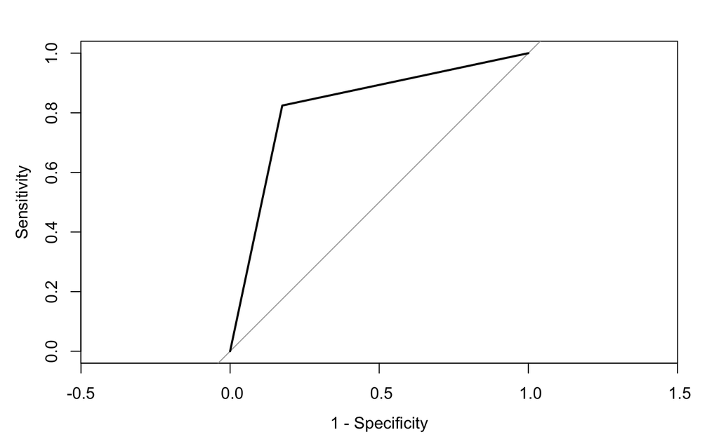

```r
library(pROC)
resRoc <- roc(data.test$cat2 ~ as.numeric(fitted.results))
plot(resRoc, legacy.axes = TRUE)
```

```r
library(rms)
auc(data.test$cat2, as.numeric(fitted.results))
```

```
Area under the curve: 0.8246
```

# Interpretación del modelo

Ahora que ya se ha construido el modelo definitivo se procede a su interpretación:

```r
anova(refined.model, test = "Chisq")
```

```
Analysis of Deviance Table

Model: binomial, link: logit

Response: cat2

Terms added sequentially (first to last)

         Df Deviance Resid. Df Resid. Dev  Pr(>Chi)
NULL                      3375     4667.1
DENSIDAD  2    17.69      3373     4649.4 0.0001441 ***
SEXO      1    13.28      3372     4636.1 0.0002679 ***
LAB       3   258.57      3369     4377.5 < 2.2e-16 ***
REGTEN    1  1291.72      3368     3085.8 < 2.2e-16 ***
SUPERF    1    34.09      3367     3051.7 5.256e-09 ***
IMPEXAC   1   756.34      3366     2295.4 < 2.2e-16 ***
---
Signif. codes:  0 ‘***’ 0.001 ‘**’ 0.01 ‘*’ 0.05 ‘.’ 0.1 ‘ ’ 1
```

Las Deviance indican el roden de importancia de las variables así la más importante con diferencia es el régimen de tenencia de la vivienda seguido por los ingresos mensuales y la situación laboral. En menor medida influye la superficie de la vivienda, la densidad y el sexo.

Respecto a los odd ratio:

```r
coef(refined.model)
```

[output not shown]

# Árboles para cat2

En primer lugar se plantean árboles que parten de todas las variables. Para ello se emplearán las siguientes bibliotecas:

```r
library(rpart)
library(rpart.plot)
library(partykit)
library(party) #Construcción de árboles de inferencia
```

## Árbol con todas las variables

```r
general_tree <- rpart(cat2 ~ ., data = data.train, method = "class",
                      parms = list(split = "information"))
print(general_tree)
```

```
n= 3376

node), split, n, loss, yval, (yprob)
      * denotes terminal node

1) root 3376 1583 0 (0.53110190 0.46889810)
  2) REGTEN=0 1102   92 0 (0.91651543 0.08348457)
    4) IMPEXAC< 1.745658 1040   38 0 (0.96346154 0.03653846) *
    5) IMPEXAC>=1.745658 62    8 1 (0.12903226 0.87096774) *
  3) REGTEN=1 2274  783 1 (0.34432718 0.65567282)
    6) IMPEXAC< -0.5790221 649   89 0 (0.86286595 0.13713405) *
    7) IMPEXAC>=-0.5790221 1625  223 1 (0.13723077 0.86276923) *
```

```r
summary(general_tree)
```

```
Call:
rpart(formula = cat2 ~ ., data = data.train, method = "class",
    parms = list(split = "information"))
  n= 3376

          CP nsplit rel error    xerror       xstd
1 0.44725205      0 1.0000000 1.0000000 0.01831675
2 0.29753632      1 0.5527479 0.5527479 0.01608343
3 0.02905875      2 0.2552116 0.2602653 0.01201450
4 0.01000000      3 0.2261529 0.2318383 0.01142515

Variable importance
IMPEXAC  REGTEN     LAB    EDAD  SUPERF
     42      34      12      10       3

Node number 1: 3376 observations,    complexity param=0.4472521
  predicted class=0  expected loss=0.4688981  P(node) =1
    class counts:  1793  1583
   probabilities: 0.531 0.469
  left son=2 (1102 obs) right son=3 (2274 obs)
  Primary splits:
      REGTEN  splits as  LR, improve=552.88970, (0 missing)
      IMPEXAC < -0.5829689  to the left,  improve=337.62370, (0 missing)
      LAB     splits as  RLLR, improve=112.86790, (0 missing)
      EDAD    < -0.06571927 to the left,  improve= 91.18571, (0 missing)
      SUPERF  < 0.2698194   to the left,  improve= 40.78812, (0 missing)
  Surrogate splits:
      EDAD    < -0.681336   to the left,  agree=0.766, adj=0.284, (0 split)
      LAB     splits as  LLRR, agree=0.738, adj=0.198, (0 split)
      SUPERF  < -1.137105   to the left,  agree=0.693, adj=0.058, (0 split)
      ESTUD   splits as  RRRL, agree=0.677, adj=0.009, (0 split)
      IMPEXAC < 3.461212    to the right, agree=0.674, adj=0.001, (0 split)

Node number 2: 1102 observations,    complexity param=0.02905875
  predicted class=0  expected loss=0.08348457  P(node) =0.3264218
    class counts:  1010    92
   probabilities: 0.917 0.083
  left son=4 (1040 obs) right son=5 (62 obs)
  Primary splits:
      IMPEXAC < 1.745658    to the left,  improve=129.597100, (0 missing)
```

[output cut: 26 more lines]

```

Node number 5: 62 observations
  predicted class=1  expected loss=0.1290323  P(node) =0.01836493
    class counts:     8    54
   probabilities: 0.129 0.871

Node number 6: 649 observations
  predicted class=0  expected loss=0.1371341  P(node) =0.1922393
    class counts:   560    89
   probabilities: 0.863 0.137

Node number 7: 1625 observations
  predicted class=1  expected loss=0.1372308  P(node) =0.4813389
    class counts:   223  1402
   probabilities: 0.137 0.863
```

Se muestra una tabla con la complejidad paramétrica:

```r
general_tree$cptable
```

```
          CP nsplit rel error    xerror       xstd
1 0.44725205      0 1.0000000 1.0000000 0.01831675
2 0.29753632      1 0.5527479 0.5527479 0.01608343
3 0.02905875      2 0.2552116 0.2602653 0.01201450
4 0.01000000      3 0.2261529 0.2318383 0.01142515
```

Y se grafica la curva:

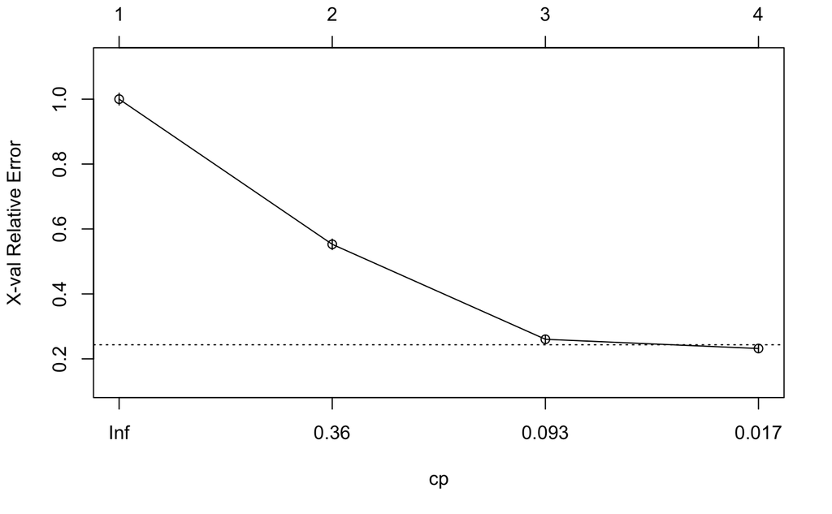

```r
plotcp(general_tree)
```

Se debe podar en el punto con el menor error relativo asociado así que se elige en este caso 0.017.

```r
pruned_general_tree <- prune(general_tree, cp = 0.017)
```

Tras ello representamos el árbol:

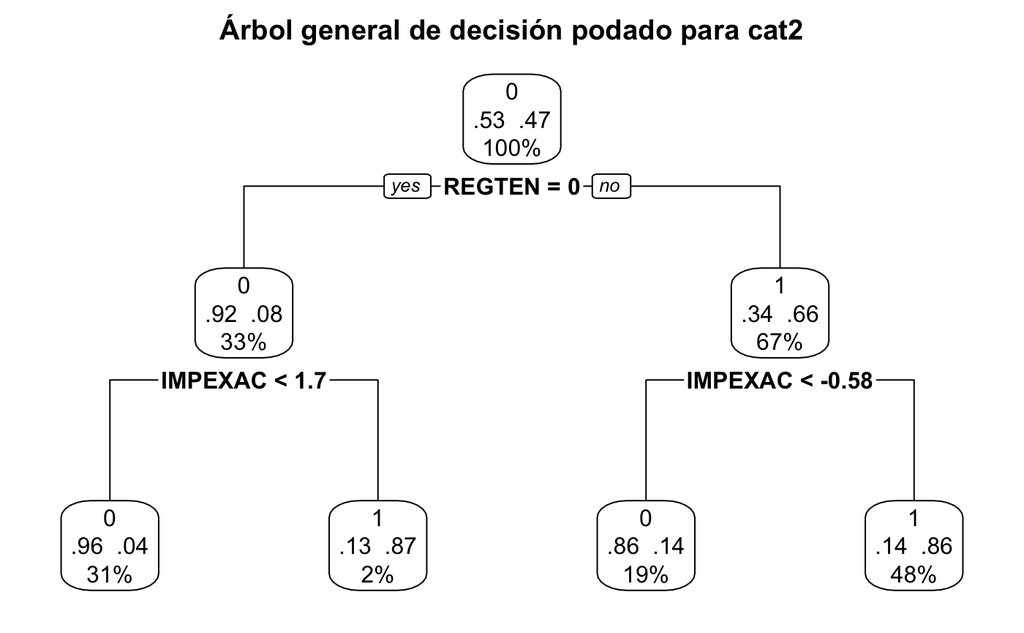

```r
prp(pruned_general_tree, type = 2, extra = 104,
fallen.leaves = TRUE, main = "Árbol general de decisión podado para cat2")
```

Para medir la bondad de este árbol se procede a predecir sobre el conjunto de test. Predecimos en primer lugar sobre el árbol general:

```r
pred_general_tree <- predict(general_tree, data.test, type = "class")
general_pred_table <- table(data.test$cat2, pred_general_tree, dnn = c("Actual", "Predicted"))
general_pred_table
```

```
      Predicted
Actual   0   1
     0 353  64
     1  38 389
```

```r
sum(diag(general_pred_table))/dim(data.test)[1]
```

```
[1] 0.8791469
```

Y para el árbol podado:

```r
pred_general_pruned_tree <- predict(pruned_general_tree, data.test, type = "class")
general_pruned_pred_table <- table(data.test$cat2, pred_general_pruned_tree, dnn = c("Actual", "Predicted"))
general_pruned_pred_table
```

```
      Predicted
Actual   0   1
     0 353  64
     1  38 389
```

```r
sum(diag(general_pruned_pred_table))/dim(data.test)[1]
```

```
[1] 0.8791469
```

Ambos árboles dan la misma matriz de confusión y la misma exactitud.

# Árbol de inferencia

Se procede a construir un árbol de inferencia a partir de todas las variables:

[figure not shown]

```r
general_inference_tree <- ctree(cat2~., data = data.train)
plot(general_inference_tree, main = "Árbol general de inferencia")
```

De nuevo se testea obteniendo la matriz de confusión:

```r
pred_conditional_general_tree <- predict(general_inference_tree, data.test, type = "response")
general_conditional_pred_table <- table(data.test$cat2, pred_conditional_general_tree, dnn = c("Actual", "Predicted"))
general_conditional_pred_table
```

```
      Predicted
Actual   0   1
     0 357  60
     1  40 387
```

y la exactitud:

```r
sum(diag(general_conditional_pred_table))/dim(data.test)[1]
```

```
[1] 0.8815166
```

## Árbol seleccionando variables

En el apartado anterior se comprobaron que variables eran signficativas para la clasificación por lo que se procede a la construcción de un árbol a partir de dichas variables:

```r
selected_tree <- rpart(cat2 ~ DENSIDAD + SEXO + LAB + REGTEN + SUPERF + IMPEXAC, data = data.train, method = "class",
                      parms = list(split = "information"))
print(selected_tree)
```

```
n= 3376

node), split, n, loss, yval, (yprob)
      * denotes terminal node

1) root 3376 1583 0 (0.53110190 0.46889810)
  2) REGTEN=0 1102   92 0 (0.91651543 0.08348457)
    4) IMPEXAC< 1.745658 1040   38 0 (0.96346154 0.03653846) *
    5) IMPEXAC>=1.745658 62    8 1 (0.12903226 0.87096774) *
  3) REGTEN=1 2274  783 1 (0.34432718 0.65567282)
    6) IMPEXAC< -0.5790221 649   89 0 (0.86286595 0.13713405) *
    7) IMPEXAC>=-0.5790221 1625  223 1 (0.13723077 0.86276923) *
```

```r
summary(selected_tree)
```

```
Call:
rpart(formula = cat2 ~ DENSIDAD + SEXO + LAB + REGTEN + SUPERF +
    IMPEXAC, data = data.train, method = "class", parms = list(split = "information"))
  n= 3376

          CP nsplit rel error    xerror       xstd
1 0.44725205      0 1.0000000 1.0000000 0.01831675
2 0.29753632      1 0.5527479 0.5527479 0.01608343
3 0.02905875      2 0.2552116 0.2552116 0.01191332
4 0.01000000      3 0.2261529 0.2280480 0.01134267

Variable importance
IMPEXAC  REGTEN     LAB  SUPERF
     46      37      14       3

Node number 1: 3376 observations,    complexity param=0.4472521
  predicted class=0  expected loss=0.4688981  P(node) =1
    class counts:  1793  1583
   probabilities: 0.531 0.469
  left son=2 (1102 obs) right son=3 (2274 obs)
  Primary splits:
      REGTEN   splits as  LR, improve=552.889700, (0 missing)
      IMPEXAC  < -0.5829689 to the left,  improve=337.623700, (0 missing)
      LAB      splits as  RLLR, improve=112.867900, (0 missing)
      SUPERF   < 0.2698194  to the left,  improve= 40.788120, (0 missing)
      DENSIDAD splits as  RLR, improve=  7.762448, (0 missing)
  Surrogate splits:
      LAB     splits as  LLRR, agree=0.738, adj=0.198, (0 split)
      SUPERF  < -1.137105  to the left,  agree=0.693, adj=0.058, (0 split)
      IMPEXAC < 3.461212   to the right, agree=0.674, adj=0.001, (0 split)

Node number 2: 1102 observations,    complexity param=0.02905875
  predicted class=0  expected loss=0.08348457  P(node) =0.3264218
    class counts:  1010    92
   probabilities: 0.917 0.083
  left son=4 (1040 obs) right son=5 (62 obs)
  Primary splits:
      IMPEXAC  < 1.745658   to the left,  improve=129.597100, (0 missing)
      LAB      splits as  RLLR, improve= 17.521820, (0 missing)
      SUPERF   < 0.4360923  to the left,  improve=  8.395609, (0 missing)
```

[output cut: 24 more lines]

```

Node number 5: 62 observations
  predicted class=1  expected loss=0.1290323  P(node) =0.01836493
    class counts:     8    54
   probabilities: 0.129 0.871

Node number 6: 649 observations
  predicted class=0  expected loss=0.1371341  P(node) =0.1922393
    class counts:   560    89
   probabilities: 0.863 0.137

Node number 7: 1625 observations
  predicted class=1  expected loss=0.1372308  P(node) =0.4813389
    class counts:   223  1402
   probabilities: 0.137 0.863
```

Se muestra una tabla con la complejidad paramétrica:

```r
selected_tree$cptable
```

```
          CP nsplit rel error    xerror       xstd
1 0.44725205      0 1.0000000 1.0000000 0.01831675
2 0.29753632      1 0.5527479 0.5527479 0.01608343
3 0.02905875      2 0.2552116 0.2552116 0.01191332
4 0.01000000      3 0.2261529 0.2280480 0.01134267
```

Y se grafica la curva:

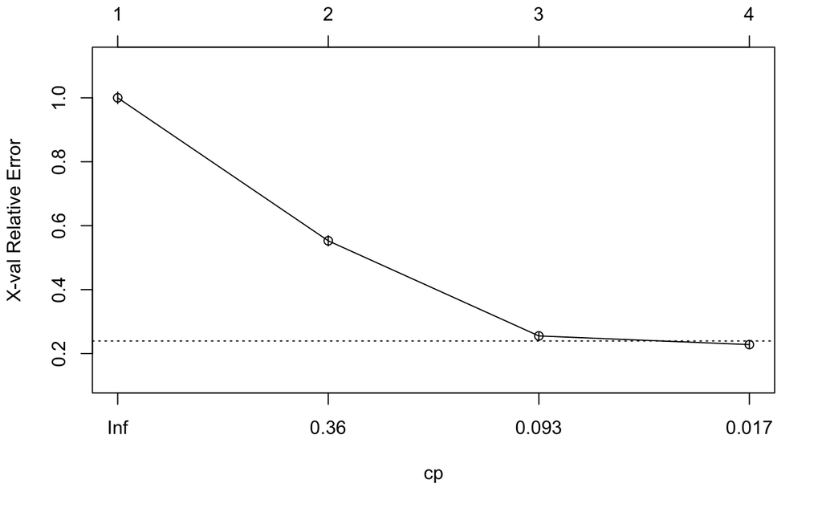

```r
plotcp(selected_tree)
```

Se debe podar en el punto con el menor error relativo asociado así que se elige en este caso 0.017.

```r
pruned_selected_tree <- prune(general_tree, cp = 0.017)
```

Tras ello representamos el árbol:

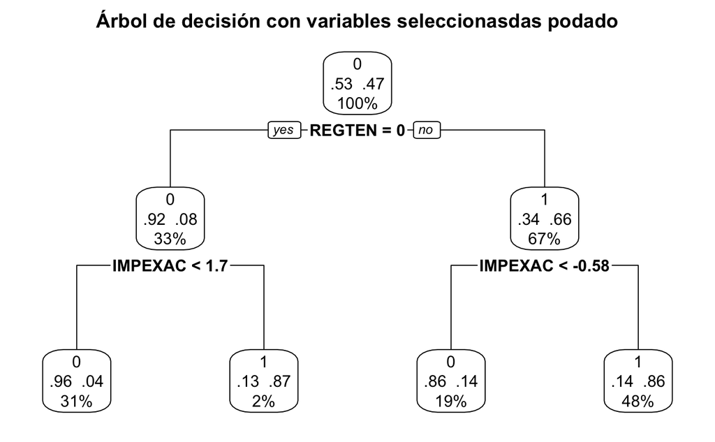

```r
prp(pruned_selected_tree, type = 2, extra = 104,
fallen.leaves = TRUE, main = "Árbol de decisión con variables seleccionasdas podado")
```

Para medir la bondad de este árbol se procede a predecir sobre el conjunto de test. Predecimos en primer lugar sobre el árbol sin podar:

```r
pred_selected_tree <- predict(selected_tree, data.test, type = "class")
selected_pred_table <- table(data.test$cat2, pred_selected_tree, dnn = c("Actual", "Predicted"))
selected_pred_table
```

```
      Predicted
Actual   0   1
     0 353  64
     1  38 389
```

Calculamos el accuracy:

```r
sum(diag(selected_pred_table))/dim(data.test)[1]
```

```
[1] 0.8791469
```

Procedemos con el árbol podado:

```r
pred_selected_pruned_tree <- predict(pruned_selected_tree, data.test, type = "class")
selected_pruned_pred_table <- table(data.test$cat2, pred_selected_pruned_tree, dnn = c("Actual", "Predicted"))
selected_pruned_pred_table
```

```
      Predicted
Actual   0   1
     0 353  64
     1  38 389
```

Y de nuevo se obtiene el accuracy:

```r
sum(diag(selected_pruned_pred_table))/dim(data.test)[1]
```

```
[1] 0.8791469
```

HASTA AQUÍ EL APARTADO B DEL EXAMEN.

# Árboles para cat3

En primer lugar se plantean árboles que parten de todas las variables. Para ello se emplearán las siguientes bibliotecas:

```r
library(rpart)
library(rpart.plot)
library(partykit)
library(party) #Construcción de árboles de inferencia
```

Para proceder a la construcción de los árboles es necesario construir conjuntos de entrenamiento y test distintos a los anteriores:

```r
datacat3 <- data[,-10]
datacat3$SUPERF <- scale(datacat3$SUPERF)
datacat3$EDAD <- scale(datacat3$EDAD)
datacat3$IMPEXAC <- scale(datacat3$IMPEXAC)
```

Una vez hecho esto se procede al análisis logístico:

En primer lugar se fija una semilla para garantizar la reproductibilidad del experimento. Tras ello se divide la base de datos en una muestra de entrenamiento y otra de test:

```r
set.seed(1234)
train <- sample(nrow(datacat3), 0.7*nrow(datacat3))
data.train2 <- datacat3[train,]
data.test2 <- datacat3[-train,]
```

## Árbol con todas las variables

```r
general_tree3 <- rpart(cat3 ~ ., data = data.train2, method = "class",
                      parms = list(split = "information"))
print(general_tree3)
```

```
n= 2954

node), split, n, loss, yval, (yprob)
      * denotes terminal node

 1) root 2954 1903 1 (0.355788761 0.342924848 0.301286391)
   2) REGTEN=0 975  283 1 (0.709743590 0.249230769 0.041025641)
     4) IMPEXAC< 0.6754107 729   77 1 (0.894375857 0.101508916 0.004115226) *
     5) IMPEXAC>=0.6754107 246   77 2 (0.162601626 0.686991870 0.150406504) *
   3) REGTEN=1 1979 1129 3 (0.181404750 0.389085397 0.429509853)
     6) IMPEXAC< -0.05146305 1199  521 2 (0.278565471 0.565471226 0.155963303)
      12) IMPEXAC< -0.7730744 244   55 1 (0.774590164 0.159836066 0.065573770) *
      13) IMPEXAC>=-0.7730744 955  316 2 (0.151832461 0.669109948 0.179057592) *
     7) IMPEXAC>=-0.05146305 780  117 3 (0.032051282 0.117948718 0.850000000) *
```

```r
summary(general_tree3)
```

```
Call:
rpart(formula = cat3 ~ ., data = data.train2, method = "class",
    parms = list(split = "information"))
  n= 2954

          CP nsplit rel error    xerror       xstd
1 0.25801366      0 1.0000000 1.0000000 0.01367341
2 0.07882291      2 0.4839727 0.4839727 0.01322984
3 0.06778770      3 0.4051498 0.4051498 0.01254325
4 0.01000000      4 0.3373621 0.3394640 0.01180566

Variable importance
IMPEXAC  REGTEN     LAB   ESTUD    EDAD  SUPERF
     46      24      13       8       7       2

Node number 1: 2954 observations,    complexity param=0.2580137
  predicted class=1  expected loss=0.6442112  P(node) =1
    class counts:  1051  1013   890
   probabilities: 0.356 0.343 0.301
  left son=2 (975 obs) right son=3 (1979 obs)
  Primary splits:
      REGTEN  splits as  LR, improve=477.3810, (0 missing)
      IMPEXAC < -0.09027351 to the left,  improve=291.5862, (0 missing)
      LAB     splits as  RLLR, improve=119.3862, (0 missing)
      EDAD    < 0.1189657   to the left,  improve=100.1470, (0 missing)
      ESTUD   splits as  LRRR, improve= 66.1469, (0 missing)
  Surrogate splits:
      EDAD    < -0.681336   to the left,  agree=0.762, adj=0.279, (0 split)
      LAB     splits as  LLRR, agree=0.734, adj=0.195, (0 split)
      SUPERF  < -1.034783   to the left,  agree=0.691, adj=0.064, (0 split)
      ESTUD   splits as  RRRL, agree=0.675, adj=0.016, (0 split)
      IMPEXAC < 3.461212    to the right, agree=0.671, adj=0.003, (0 split)

Node number 2: 975 observations,    complexity param=0.0677877
  predicted class=1  expected loss=0.2902564  P(node) =0.3300609
    class counts:   692   243    40
   probabilities: 0.710 0.249 0.041
  left son=4 (729 obs) right son=5 (246 obs)
  Primary splits:
      IMPEXAC < 0.6754107   to the left,  improve=237.870000, (0 missing)
```

[output cut: 49 more lines]

```

Node number 7: 780 observations
  predicted class=3  expected loss=0.15  P(node) =0.2640487
    class counts:    25    92   663
   probabilities: 0.032 0.118 0.850

Node number 12: 244 observations
  predicted class=1  expected loss=0.2254098  P(node) =0.08259986
    class counts:   189    39    16
   probabilities: 0.775 0.160 0.066

Node number 13: 955 observations
  predicted class=2  expected loss=0.3308901  P(node) =0.3232905
    class counts:   145   639   171
   probabilities: 0.152 0.669 0.179
```

Se muestra una tabla con la complejidad paramétrica:

```r
general_tree3$cptable
```

```
          CP nsplit rel error    xerror       xstd
1 0.25801366      0 1.0000000 1.0000000 0.01367341
2 0.07882291      2 0.4839727 0.4839727 0.01322984
3 0.06778770      3 0.4051498 0.4051498 0.01254325
4 0.01000000      4 0.3373621 0.3394640 0.01180566
```

Y se grafica la curva:

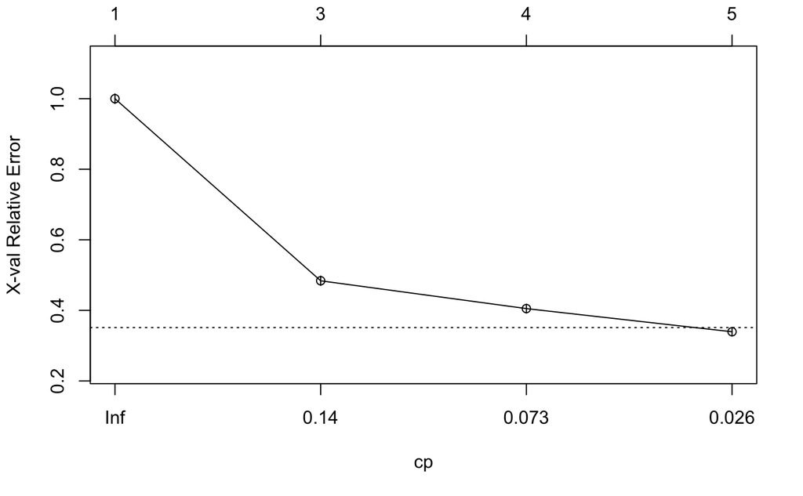

```r
plotcp(general_tree3)
```

Se debe podar en el punto con el menor error relativo asociado así que se elige en este caso 0.026.

```r
pruned_general_tree3 <- prune(general_tree3, cp = 0.026)
```

Tras ello representamos el árbol:

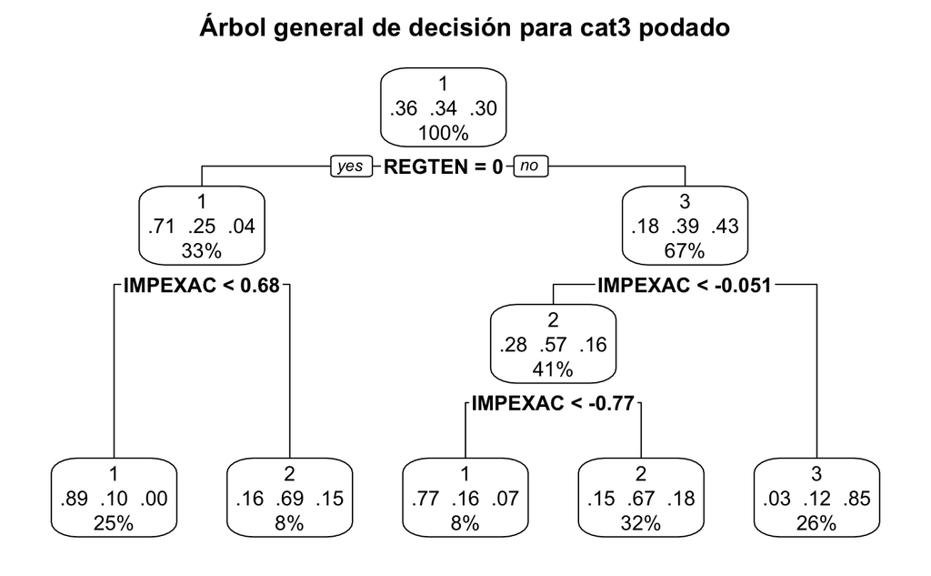

```r
prp(pruned_general_tree3, type = 2, extra = 104,
fallen.leaves = TRUE, main = "Árbol general de decisión para cat3 podado")
```

Para medir la bondad de este árbol se procede a predecir sobre el conjunto de test. Predecimos en primer lugar sobre el árbol general:

```r
pred_general_tree3 <- predict(general_tree3, data.test2, type = "class")
general_pred_table3 <- table(data.test2$cat3, pred_general_tree3, dnn = c("Actual", "Predicted"))
general_pred_table3
```

```
      Predicted
Actual   1   2   3
     1 320  86  15
     2  58 361  41
     3   9  82 294
```

```r
sum(diag(general_pred_table3))/dim(data.test2)[1]
```

```
[1] 0.7701422
```

Y para el árbol podado:

```r
pred_general_pruned_tree3 <- predict(pruned_general_tree3, data.test2, type = "class")
general_pruned_pred_table3 <- table(data.test2$cat3, pred_general_pruned_tree3, dnn = c("Actual", "Predicted"))
general_pruned_pred_table3
```

```
      Predicted
Actual   1   2   3
     1 320  86  15
     2  58 361  41
     3   9  82 294
```

```r
sum(diag(general_pruned_pred_table3))/dim(data.test2)[1]
```

```
[1] 0.7701422
```

Ambos árboles dan la misma matriz de confusión y la misma exactitud de nuevo.

### Explicación del árbol

La variable con mayor poder de decisión es el régimen de tenencia seguida de los ingresos mensuales. Se basta de estas dos variables para realizar la predicción.

# Árbol de inferencia

Se procede a construir un árbol de inferencia a partir de todas las variables:

[figure not shown]

```r
general_inference_tree3 <- ctree(cat3~., data = data.train2)
plot(general_inference_tree3, main = "Árbol general de inferencia")
```

De nuevo se testea obteniendo la matriz de confusión:

```r
pred_conditional_general_tree3 <- predict(general_inference_tree3, data.test2, type = "response")
general_conditional_pred_table3 <- table(data.test2$cat3, pred_conditional_general_tree3, dnn = c("Actual", "Predicted"))
general_conditional_pred_table3
```

```
      Predicted
Actual   1   2   3
     1 325  79  17
     2  66 349  45
     3   9  64 312
```

y la exactitud:

```r
sum(diag(general_conditional_pred_table3))/dim(data.test2)[1]
```

```
[1] 0.778831
```

## Árbol seleccionando variables

Para seleccionar variables se decide llevar a cabo una regresión sobre la variable cat3:

```r
library(glmnet)
X_train <- model.matrix(cat3 ~., data.train2)[,-11]
y_train <- data.train2$cat3
X_test <- model.matrix(cat3 ~., data.test2)[,-11]
y_test <- data.test2$cat3
```

```r
fit = glmnet(X_train, y_train, family = "multinomial", type.multinomial = "grouped")
cvfit=cv.glmnet(X_train, y_train, family="multinomial", type.multinomial = "grouped", parallel = TRUE)
```

```
executing %dopar% sequentially: no parallel backend registered
```

```r
prediction_cat3 <- predict(cvfit, newx = X_test, s = "lambda.min", type = "class")
```

Una vez hecha la predicción construimos de nuevo la matriz de confusión:

```r
(mat_cat3 <- table(data.test2$cat3, prediction_cat3, dnn = c("Actual", "Predicted")))
```

```
      Predicted
Actual   1   2   3
     1 317  88  16
     2  57 348  55
     3   9  66 310
```

```r
sum(diag(mat_cat3))/dim(data.test2)[1]
```

```
[1] 0.7701422
```

```r
coef(cvfit)
```

```
$`1`
15 x 1 sparse Matrix of class "dgCMatrix"
                       1
(Intercept)  2.491215426
(Intercept)  .
TAMAMU1     -0.002072062
DENSIDAD2    0.094718387
DENSIDAD3    0.064908819
EDAD         0.000313460
SEXO1        0.020900612
ESTUD2       .
ESTUD3       0.017888539
ESTUD4       0.004759016
LAB2         0.132176961
LAB4         0.100026383
REGTEN1     -4.193986122
SUPERF       .
IMPEXAC     -2.369127050

$`2`
15 x 1 sparse Matrix of class "dgCMatrix"
                       1
(Intercept)  0.879260317
(Intercept)  .
TAMAMU1     -0.014596365
DENSIDAD2   -0.026633290
DENSIDAD3    0.072448580
EDAD         0.007075777
SEXO1       -0.020603711
ESTUD2       .
ESTUD3      -0.040186940
ESTUD4      -0.111026264
LAB2         0.034265619
LAB4         0.281750626
REGTEN1     -0.383986664
SUPERF       .
IMPEXAC      0.222766931

$`3`
15 x 1 sparse Matrix of class "dgCMatrix"
                        1
(Intercept) -3.3704757436
(Intercept)  .
TAMAMU1      0.0166684270
DENSIDAD2   -0.0680850973
DENSIDAD3   -0.1373573994
EDAD        -0.0073892372
SEXO1       -0.0002969008
ESTUD2       .
ESTUD3       0.0222984013
ESTUD4       0.1062672481
LAB2        -0.1664425795
LAB4        -0.3817770087
REGTEN1      4.5779727861
SUPERF       .
IMPEXAC      2.1463601195
```

Se descarta la variable SUPERFICIE. Construimos un árbol sin ellas:

```r
selected_tree <- rpart(cat3 ~ TAMAMU + DENSIDAD + SEXO + ESTUD + LAB + REGTEN+ IMPEXAC + EDAD, data = data.train2, method = "class",
                      parms = list(split = "information"))
print(selected_tree)
```

```
n= 2954

node), split, n, loss, yval, (yprob)
      * denotes terminal node

 1) root 2954 1903 1 (0.355788761 0.342924848 0.301286391)
   2) REGTEN=0 975  283 1 (0.709743590 0.249230769 0.041025641)
     4) IMPEXAC< 0.6754107 729   77 1 (0.894375857 0.101508916 0.004115226) *
     5) IMPEXAC>=0.6754107 246   77 2 (0.162601626 0.686991870 0.150406504) *
   3) REGTEN=1 1979 1129 3 (0.181404750 0.389085397 0.429509853)
     6) IMPEXAC< -0.05146305 1199  521 2 (0.278565471 0.565471226 0.155963303)
      12) IMPEXAC< -0.7730744 244   55 1 (0.774590164 0.159836066 0.065573770) *
      13) IMPEXAC>=-0.7730744 955  316 2 (0.151832461 0.669109948 0.179057592) *
     7) IMPEXAC>=-0.05146305 780  117 3 (0.032051282 0.117948718 0.850000000) *
```

```r
summary(selected_tree)
```

```
Call:
rpart(formula = cat3 ~ TAMAMU + DENSIDAD + SEXO + ESTUD + LAB +
    REGTEN + IMPEXAC + EDAD, data = data.train2, method = "class",
    parms = list(split = "information"))
  n= 2954

          CP nsplit rel error    xerror       xstd
1 0.25801366      0 1.0000000 1.0000000 0.01367341
2 0.07882291      2 0.4839727 0.4839727 0.01322984
3 0.06778770      3 0.4051498 0.4077772 0.01256944
4 0.01000000      4 0.3373621 0.3410405 0.01182534

Variable importance
IMPEXAC  REGTEN     LAB   ESTUD    EDAD
     47      24      14       9       7

Node number 1: 2954 observations,    complexity param=0.2580137
  predicted class=1  expected loss=0.6442112  P(node) =1
    class counts:  1051  1013   890
   probabilities: 0.356 0.343 0.301
  left son=2 (975 obs) right son=3 (1979 obs)
  Primary splits:
      REGTEN  splits as  LR, improve=477.3810, (0 missing)
      IMPEXAC < -0.09027351 to the left,  improve=291.5862, (0 missing)
      LAB     splits as  RLLR, improve=119.3862, (0 missing)
      EDAD    < 0.1189657   to the left,  improve=100.1470, (0 missing)
      ESTUD   splits as  LRRR, improve= 66.1469, (0 missing)
  Surrogate splits:
      EDAD    < -0.681336   to the left,  agree=0.762, adj=0.279, (0 split)
      LAB     splits as  LLRR, agree=0.734, adj=0.195, (0 split)
      ESTUD   splits as  RRRL, agree=0.675, adj=0.016, (0 split)
      IMPEXAC < 3.461212    to the right, agree=0.671, adj=0.003, (0 split)

Node number 2: 975 observations,    complexity param=0.0677877
  predicted class=1  expected loss=0.2902564  P(node) =0.3300609
    class counts:   692   243    40
   probabilities: 0.710 0.249 0.041
  left son=4 (729 obs) right son=5 (246 obs)
  Primary splits:
      IMPEXAC  < 0.6754107   to the left,  improve=237.870000, (0 missing)
```

[output cut: 45 more lines]

```

Node number 7: 780 observations
  predicted class=3  expected loss=0.15  P(node) =0.2640487
    class counts:    25    92   663
   probabilities: 0.032 0.118 0.850

Node number 12: 244 observations
  predicted class=1  expected loss=0.2254098  P(node) =0.08259986
    class counts:   189    39    16
   probabilities: 0.775 0.160 0.066

Node number 13: 955 observations
  predicted class=2  expected loss=0.3308901  P(node) =0.3232905
    class counts:   145   639   171
   probabilities: 0.152 0.669 0.179
```

Se muestra una tabla con la complejidad paramétrica:

```r
selected_tree$cptable
```

```
          CP nsplit rel error    xerror       xstd
1 0.25801366      0 1.0000000 1.0000000 0.01367341
2 0.07882291      2 0.4839727 0.4839727 0.01322984
3 0.06778770      3 0.4051498 0.4077772 0.01256944
4 0.01000000      4 0.3373621 0.3410405 0.01182534
```

Y se grafica la curva:

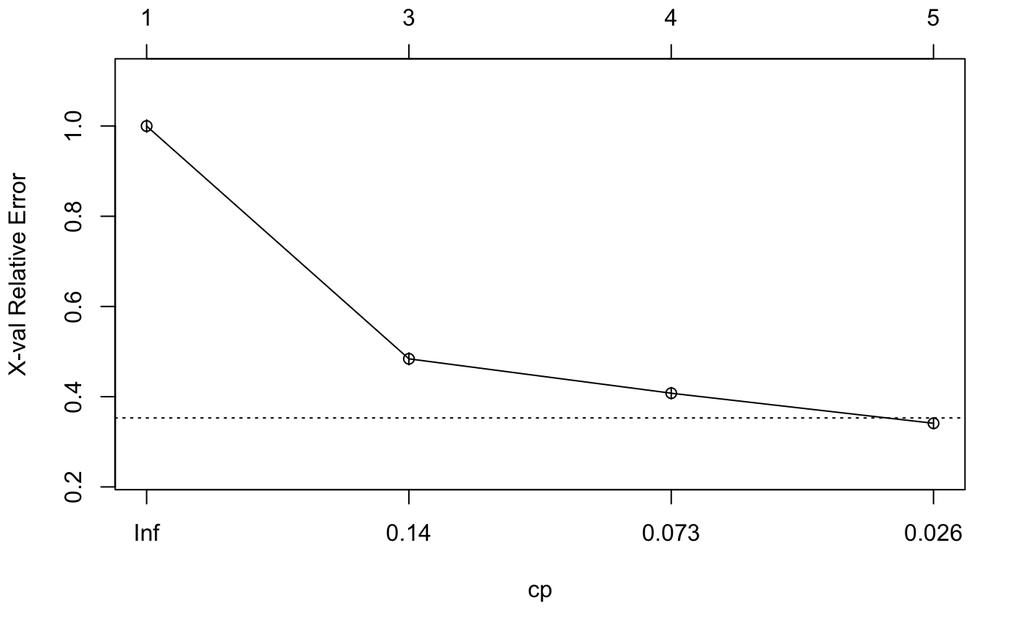

```r
plotcp(selected_tree)
```

Se debe podar en el punto con el menor error relativo asociado así que se elige en este caso 0.026.

```r
pruned_selected_tree <- prune(selected_tree, cp = 0.026)
```

Tras ello representamos el árbol:

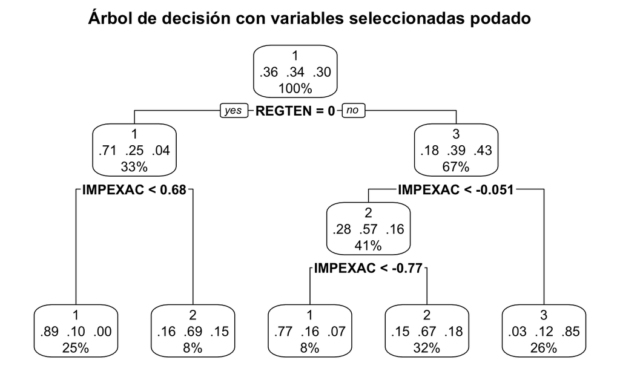

```r
prp(pruned_selected_tree, type = 2, extra = 104,
fallen.leaves = TRUE, main = "Árbol de decisión con variables seleccionadas podado")
```

Se obtiene el mismo árbol que sin selección de variables.

Parece que esta técnica de selección de variables no ha devuelvo una solución muy eficiente por lo que se procede a probar alguna técnica diferente.

Tras distinta experimentaciones se observa que las únicas dos variables empleadas para la clasificación son el régimen de tenencia y los ingresos mensuales. En el momento en que una de las dos es eliminada se aprecia una pérdida de calidad en el modelo, así pues se decide construir un árbo basado únicamente en dichas variables. Mediante un test anova y una tabla de contingencia se confirma dicha importancia:

```r
corr_cat3_ingesos <- lm(data$IMPEXAC ~ data$cat3, data = data)
anova(corr_cat3_ingesos)
```

```
Analysis of Variance Table

Response: data$IMPEXAC
            Df Sum Sq Mean Sq F value    Pr(>F)
data$cat3    2  49650   24825  539.32 < 2.2e-16 ***
Residuals 4217 194107      46
---
Signif. codes:  0 ‘***’ 0.001 ‘**’ 0.01 ‘*’ 0.05 ‘.’ 0.1 ‘ ’ 1
```

```r
library(vcd)
tab <- xtabs(~ data$REGTEN + data$cat3, data = data)
summary(assocstats(tab))
```

```
Call: xtabs(formula = ~data$REGTEN + data$cat3, data = data)
Number of cases in table: 4220
Number of factors: 2
Test for independence of all factors:
    Chisq = 1198, df = 2, p-value = 7.063e-261
                  X^2 df P(> X^2)
Likelihood Ratio 1289  2        0
Pearson          1198  2        0

Phi-Coefficient   : NA
Contingency Coeff.: 0.47
Cramer's V        : 0.533
```

Así pues se construye un último árbol a partir de estas dos variables:

```r
last_tree <- rpart(cat3 ~ REGTEN + IMPEXAC, data = data.train2, method = "class",
                      parms = list(split = "information"))
print(last_tree)
```

```
n= 2954

node), split, n, loss, yval, (yprob)
      * denotes terminal node

 1) root 2954 1903 1 (0.355788761 0.342924848 0.301286391)
   2) REGTEN=0 975  283 1 (0.709743590 0.249230769 0.041025641)
     4) IMPEXAC< 0.6754107 729   77 1 (0.894375857 0.101508916 0.004115226) *
     5) IMPEXAC>=0.6754107 246   77 2 (0.162601626 0.686991870 0.150406504) *
   3) REGTEN=1 1979 1129 3 (0.181404750 0.389085397 0.429509853)
     6) IMPEXAC< -0.05146305 1199  521 2 (0.278565471 0.565471226 0.155963303)
      12) IMPEXAC< -0.7730744 244   55 1 (0.774590164 0.159836066 0.065573770) *
      13) IMPEXAC>=-0.7730744 955  316 2 (0.151832461 0.669109948 0.179057592) *
     7) IMPEXAC>=-0.05146305 780  117 3 (0.032051282 0.117948718 0.850000000) *
```

```r
summary(last_tree)
```

```
Call:
rpart(formula = cat3 ~ REGTEN + IMPEXAC, data = data.train2,
    method = "class", parms = list(split = "information"))
  n= 2954

          CP nsplit rel error    xerror       xstd
1 0.25801366      0 1.0000000 1.0000000 0.01367341
2 0.07882291      2 0.4839727 0.4839727 0.01322984
3 0.06778770      3 0.4051498 0.4161850 0.01265163
4 0.01000000      4 0.3373621 0.3394640 0.01180566

Variable importance
IMPEXAC  REGTEN
     66      34

Node number 1: 2954 observations,    complexity param=0.2580137
  predicted class=1  expected loss=0.6442112  P(node) =1
    class counts:  1051  1013   890
   probabilities: 0.356 0.343 0.301
  left son=2 (975 obs) right son=3 (1979 obs)
  Primary splits:
      REGTEN  splits as  LR, improve=477.3810, (0 missing)
      IMPEXAC < -0.09027351 to the left,  improve=291.5862, (0 missing)
  Surrogate splits:
      IMPEXAC < 3.461212    to the right, agree=0.671, adj=0.003, (0 split)

Node number 2: 975 observations,    complexity param=0.0677877
  predicted class=1  expected loss=0.2902564  P(node) =0.3300609
    class counts:   692   243    40
   probabilities: 0.710 0.249 0.041
  left son=4 (729 obs) right son=5 (246 obs)
  Primary splits:
      IMPEXAC < 0.6754107   to the left,  improve=237.87, (0 missing)

Node number 3: 1979 observations,    complexity param=0.2580137
  predicted class=3  expected loss=0.5704901  P(node) =0.6699391
    class counts:   359   770   850
   probabilities: 0.181 0.389 0.430
  left son=6 (1199 obs) right son=7 (780 obs)
  Primary splits:
```

[output cut: 19 more lines]

```

Node number 7: 780 observations
  predicted class=3  expected loss=0.15  P(node) =0.2640487
    class counts:    25    92   663
   probabilities: 0.032 0.118 0.850

Node number 12: 244 observations
  predicted class=1  expected loss=0.2254098  P(node) =0.08259986
    class counts:   189    39    16
   probabilities: 0.775 0.160 0.066

Node number 13: 955 observations
  predicted class=2  expected loss=0.3308901  P(node) =0.3232905
    class counts:   145   639   171
   probabilities: 0.152 0.669 0.179
```

Se comprueba a qué nivel se procederá a la poda:

```r
last_tree$cptable
```

```
          CP nsplit rel error    xerror       xstd
1 0.25801366      0 1.0000000 1.0000000 0.01367341
2 0.07882291      2 0.4839727 0.4839727 0.01322984
3 0.06778770      3 0.4051498 0.4161850 0.01265163
4 0.01000000      4 0.3373621 0.3394640 0.01180566
```

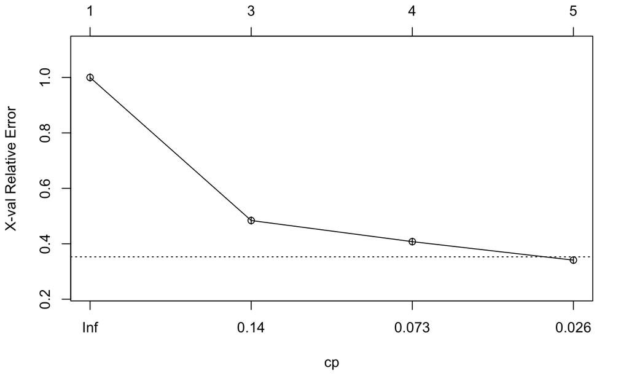

```r
plotcp(selected_tree)
```

Se debe podar en el punto con el menor error relativo asociado así que se elige en este caso 0.026.

```r
pruned_last_tree <- prune(last_tree, cp = 0.026)
```

Tras ello representamos el árbol:

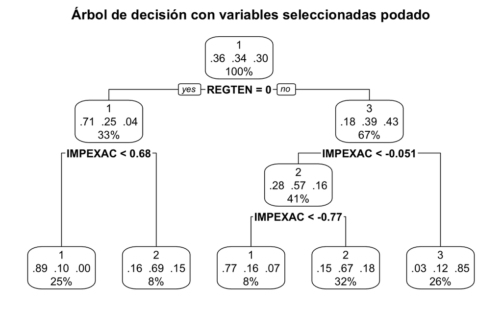

```r
prp(pruned_last_tree, type = 2, extra = 104,
fallen.leaves = TRUE, main = "Árbol de decisión con variables seleccionadas podado")
```

(Es el mismo que antes)

```r
pred_last_tree <- predict(last_tree, data.test2, type = "class")
last_pred_table <- table(data.test2$cat3, pred_last_tree, dnn = c("Actual", "Predicted"))
last_pred_table
```

```
      Predicted
Actual   1   2   3
     1 320  86  15
     2  58 361  41
     3   9  82 294
```

```r
sum(diag(last_pred_table))/dim(data.test2)[1]
```

```
[1] 0.7701422
```

Hasta aquí el código de trabajo. Para una interpretación del estudio aquí realizado ver el informe adjunto.